# 1 Learning objectives

1. You will learn how to use `for` loops to automate tasks in R.

# 2 Introduction to the dataset

In this lesson, we will use some data from the [Gapminder project](https://www.gapminder.org/).

```r
gapminder = read_csv('https://raw.githubusercontent.com/OHI-Science/data-science-training/master/data/gapminder.csv')
gapminder
```

| country | year | pop | continent | lifeExp | gdpPercap |
| --- | --- | --- | --- | --- | --- |
| Afghanistan | 1952 | 8425333 | Asia | 28.801 | 779.4453145 |
| Afghanistan | 1957 | 9240934 | Asia | 30.332 | 820.8530296 |
| Afghanistan | 1962 | 10267083 | Asia | 31.997 | 853.10071 |
| Afghanistan | 1967 | 11537966 | Asia | 34.02 | 836.1971382 |
| Afghanistan | 1972 | 13079460 | Asia | 36.088 | 739.9811058 |
| Afghanistan | 1977 | 14880372 | Asia | 38.438 | 786.11336 |
| Afghanistan | 1982 | 12881816 | Asia | 39.854 | 978.0114388 |
| Afghanistan | 1987 | 13867957 | Asia | 40.822 | 852.3959448 |
| Afghanistan | 1992 | 16317921 | Asia | 41.674 | 649.3413952 |
| Afghanistan | 1997 | 22227415 | Asia | 41.763 | 635.341351 |

[output cut: 1694 more lines]

# 3 Automation with `for` loops

For loops can be really useful to automate tasks in R.

Suppose we want to plot the variation in time of the life expectancy in Switzerland. We can do that using the code below. In the plot, we use as title: `Switzerland - lifeExp` and save the plot in the `images` folder.

```r
## filter the country to plot
gap_to_plot <- gapminder %>%
  filter(country == "Switzerland")

## plot
my_plot <- ggplot(data = gap_to_plot, aes(x = year, y = lifeExp)) +
  geom_point() +
  ## add title and save
  labs(title = "Switzerland - lifeExp")

ggsave(filename = 'Switzerland_lifeExp.png', path = here("ch05_loop_conditionals/images"), plot = my_plot)
```

[output not shown]

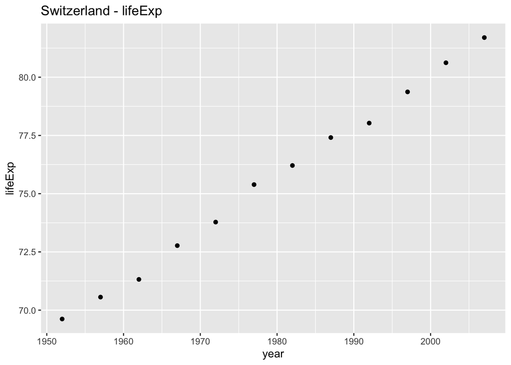

```r
my_plot
```

To be able to create this plot with another country, let’s replace the ‘Switzerland’ string by a variable called `ctry`.

```r
ctry = 'Switzerland'

gap_to_plot <- gapminder %>%
  filter(country == ctry)

## plot
my_plot <- ggplot(data = gap_to_plot, aes(x = year, y = lifeExp)) +
  geom_point() +
  ## add title and save
  labs(title = paste(ctry, " - ", "lifeExp", sep = ""))

ggsave(filename = paste(ctry, '_lifeExp.png', sep = ""), path = here("ch05_loop_conditionals/images"), plot = my_plot)
```

[output not shown]

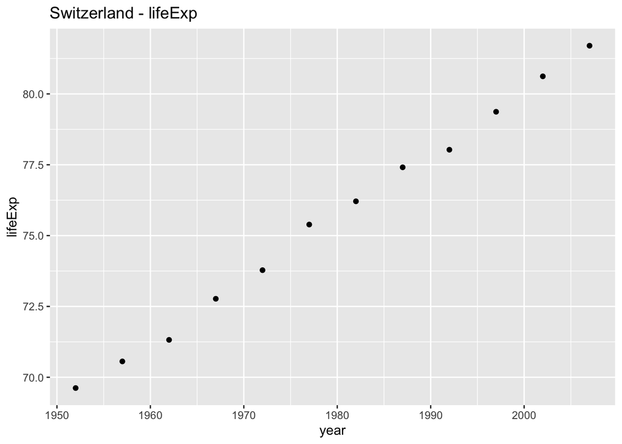

```r
my_plot
```

Suppose now, that we want to create this plot also for ‘Brazil’, ‘Colombia’ and ‘Angola’. Instead of running the code above three times, we can create a loop that given a vector, change the value of `ctry` after each iteration. Let’s do this in the code below:

```r
countries = c("Brazil", "Colombia", "Angola")

for (ctry in countries){
  gap_to_plot <- gapminder %>%
    filter(country == ctry)

  ## plot
  my_plot <- ggplot(data = gap_to_plot, aes(x = year, y = lifeExp)) +
    geom_point() +
    ## add title and save
    labs(title = paste(ctry, " - ", "lifeExp", sep = ""))

  ggsave(filename = paste(ctry, '_lifeExp.png', sep = ""), path = here("ch05_loop_conditionals/images"), plot = my_plot)
  }
```

[output not shown]

Based on the code above, select between the chunks of code below, which allows you to generate the plot for a list of countries and columns. The code must allow you to plot any column of the gapminder data set.

- A

```r
countries = c("Brazil", "Colombia", "Angola")
cols_plot = c("pop", "lifeExp","gdpPercap")

for (col in countries){
  for (ctry in cols_plot) {

    gap_to_plot <- gapminder %>%
    filter(country == ctry)

  ## plot
  my_plot <- ggplot(data = gap_to_plot, aes_string(x ="year", y = col)) +
    geom_point() +
    ## add title and save
    labs(title = paste(ctry, " - ", col, sep = ""))

  ggsave(filename = paste(ctry, '_' , col, '.png', sep = ""), path = here("ch05_loop_conditionals/images"), plot = my_plot)
  }
}
```

- B

```r
countries = c("Brazil", "Colombia", "Angola")
cols_plot = c("pop", "lifeExp","gdpPercap")

for (ctry in countries){
  for (col in cols_plot) {

    gap_to_plot <- gapminder %>%
    filter(country == ctry)

  ## plot
  my_plot <- ggplot(data = gap_to_plot, aes_string(x ="year", y = lifeExp)) +
    geom_point() +
    ## add title and save
    labs(title = paste(ctry, " - ", col, sep = ""))

  ggsave(filename = paste(ctry, '_' , 'lifeExp', '.png', sep = ""), path = here("ch05_loop_conditionals/images"), plot = my_plot)
  }
}
```

- C

```r
countries = c("Brazil", "Colombia", "Angola")
cols_plot = c("pop", "lifeExp","gdpPercap")

for (ctry in countries){
  for (col in cols_plot) {

    gap_to_plot <- gapminder %>%
    filter(country == ctry)

  ## plot
  my_plot <- ggplot(data = gap_to_plot, aes_string(x ="year", y = col)) +
    geom_point() +
    ## add title and save
    labs(title = paste(ctry, " - ", "lifeExp", sep = ""))

  ggsave(filename = paste(ctry, '_' , col, '.png', sep = ""), path = here("ch05_loop_conditionals/images"), plot = my_plot)
  }
}
```

- D

```r
countries = c("Brazil", "Colombia", "Angola")
cols_plot = c("pop", "lifeExp","gdpPercap")

for (ctry in countries){
  for (col in cols_plot) {

    gap_to_plot <- gapminder %>%
    filter(country == ctry)

  ## plot
  my_plot <- ggplot(data = gap_to_plot, aes_string(x ="year", y = col)) +
    geom_point() +
    ## add title and save
    labs(title = paste(ctry, " - ", col, sep = ""))

  ggsave(filename = paste(ctry, '_' , col, '.png', sep = ""), path = here("ch05_loop_conditionals/images"), plot = my_plot)
  }
}
```

```
## Correct! You are laudable!
##   1
```

We can also save the data filtered by country in a `.csv` file by adding the function `write.csv` in the loop.

```r
countries = c("Brazil", "Colombia", "Angola")

for (ctry in countries){
  gap_to_plot <- gapminder %>%
    filter(country == ctry)

  ## plot
  my_plot <- ggplot(data = gap_to_plot, aes(x = year, y = lifeExp)) +
    geom_point() +
    ## add title and save
    labs(title = paste(ctry, " - ", "lifeExp", sep = ""))

  setwd(here("ch05_loop_conditionals/data"))

  write.csv(gap_to_plot, paste("gapminder_",ctry, ".csv", sep = ""), row.names = FALSE)

  ggsave(filename = paste(ctry, '_lifeExp.png', sep = ""), path = here("ch05_loop_conditionals/images"), plot = my_plot)
}
```

[output not shown]

# Contributors

The following team members contributed to this lesson:

- DANIEL CAMARA  
  Data Scientist at the GRAPH Network and fellowship as Public Health researcher at Fiocruz, Brazil

  Passionate about lots of things, especially when it involves people leading lives with more equality and freedom
- [EDUARDO ARAUJO](https://thegraphcourses.org/members/eduardo_araujo/)  
  Student at Universidade Tecnologica Federal do Parana

  This is a temporary tagline
- [LAURE VANCAUWENBERGHE](https://thegraphcourses.org/members/lolovanco)  
  Data analyst, the GRAPH Network

  A firm believer in science for good, striving to ally programming, health and education.
- [KENE DAVID NWOSU](https://thegraphcourses.org/members/kendavidn/)  
  Data analyst, the GRAPH Network

  Passionate about education.

# References

Some material in this lesson was adapted from the following sources:

- The Ocean Health Index Team. “Introduction to Open Data Science.” Accessed Jun 10, 2022. http://ohi-science.org/data-science-training/programming.html#automation-with-for-loops

This work is licensed under the [Creative Commons Attribution Share Alike](https://creativecommons.org/licenses/by-sa/4.0/) license.

[figure not shown]